# 10_FCN

**Fully Convolutional Networks (FCN)**

By Prof. Seungchul Lee  
http://iailab.kaist.ac.kr/  
Industrial AI Lab at KAIST

Table of Contents

Source

- https://towardsdatascience.com/types-of-convolutions-in-deep-learning-717013397f4d
- https://github.com/vdumoulin/conv_arithmetic
- https://distill.pub/2016/deconv-checkerboard/

# 1. Convolutional Autoencoder

```python
from IPython.display import YouTubeVideo
YouTubeVideo('sKDv7yp3Jdk?si=zflwWs4XaLljHfNC', width = "560", height = "315")
```

[video not shown]

## 1.1. 2D Convolution

```
tf.keras.layers.Conv2D(filters, kernel_size, strides, padding, activation, kernel_regularizer, input_shape)
    filters = 32
    kernel_size = (3,3)
    strides = (1,1)
    padding = 'SAME'
    activeation='relu'
    kernel_regularizer=tf.keras.regularizers.l2(0.04)
    input_shape = tensor of shape([input_h, input_w, input_ch])
```

**Examples**

```
input = [None, 4, 4, 1]
filter size = [3, 3, 1, 1]
strides = [1, 1, 1, 1]
padding = 'VALID'
```

```
input = [None, 5, 5, 1]
filter size = [3, 3, 1, 1]
strides = [1, 1, 1, 1]
padding = 'SAME'
```

## 1.2. Transposed Convolution

- The need for transposed convolutions generally arises from the desire to use a transformation going in the opposite direction of a normal convolution, i.e., from something that has the shape of the output of some convolution to something that has the shape of its input while maintaining a connectivity pattern that is compatible with said convolution. For instance, one might use such a transformation as the decoding layer of a convolutional autoencoder or to project feature maps to a higher-dimensional space.
- Some sources use the name deconvolution, which is inappropriate because it’s not a deconvolution. To make things worse deconvolutions do exists, but they’re not common in the field of deep learning.
- An actual deconvolution reverts the process of a convolution.
- Imagine inputting an image into a single convolutional layer. Now take the output, throw it into a black box and out comes your original image again. This black box does a deconvolution. It is the mathematical inverse of what a convolutional layer does.
- A transposed convolution is somewhat similar because it produces the same spatial resolution a hypothetical deconvolutional layer would. However, the actual mathematical operation that’s being performed on the values is different.
- A transposed convolutional layer carries out a regular convolution but reverts its spatial transformation.

```
tf.keras.layers.Conv2DTranspose(filters, kernel_size, strides, padding = 'SAME', activation)
    filter = number of channels/ 64
    kernel_size = tensor of shape (3,3)
    strides = stride of the sliding window for each dimension of the input tensor
    padding = 'SAME'
    activation = activation functions('softmax', 'relu' ...)
```

- `'SAME'` : enable zero padding
- `'VALID'` : disable zero padding

An image of 5x5 is fed into a convolutional layer. The stride is set to 2, the padding is deactivated and the kernel is 3x3. This results in a 2x2 image.

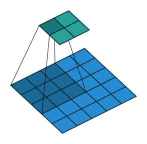

If we wanted to reverse this process, we’d need the inverse mathematical operation so that 9 values are generated from each pixel we input. Afterward, we traverse the output image with a stride of 2. This would be a deconvolution.

A transposed convolution does not do that. The only thing in common is it guarantees that the output will be a 5x5 image as well, while still performing a normal convolution operation. To achieve this, we need to perform some fancy padding on the input.

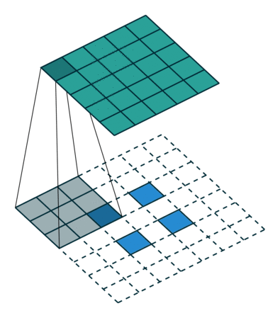

Transposed 2D convolution with no padding, stride of 2 and kernel of 3

It merely reconstructs the spatial resolution from before and performs a convolution. This may not be the mathematical inverse, but for Encoder-Decoder architectures, it’s still very helpful. This way we can combine the upscaling of an image with a convolution, instead of doing two separate processes.

- Another example of transposed convolution

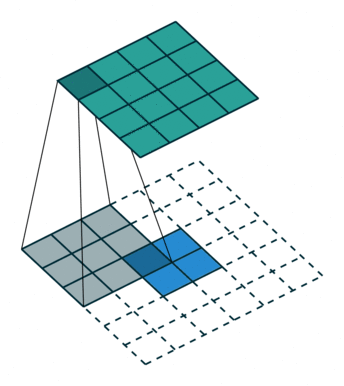

Transposed 2D convolution with no padding, no stride and kernel of 3

**Strides and padding for transposed convolution (optional)**

- Source
  - A guide to convolution arithmetic for deep learning by Vincent Dumoulin and Francesco Visin
  - https://github.com/vdumoulin/conv_arithmetic

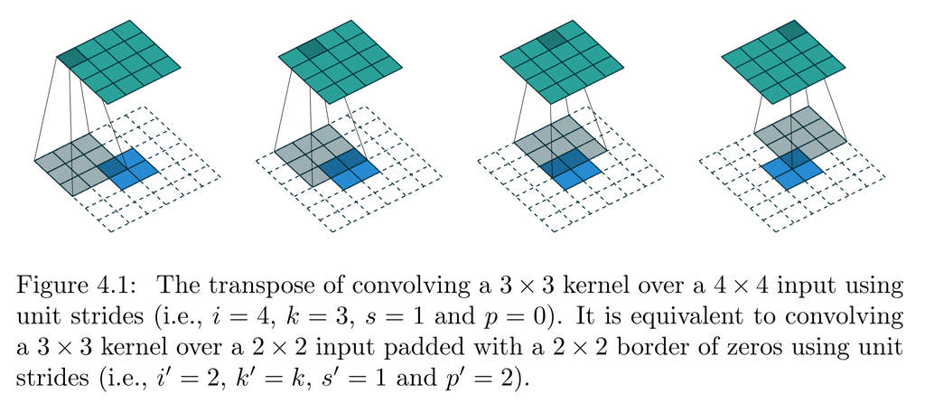

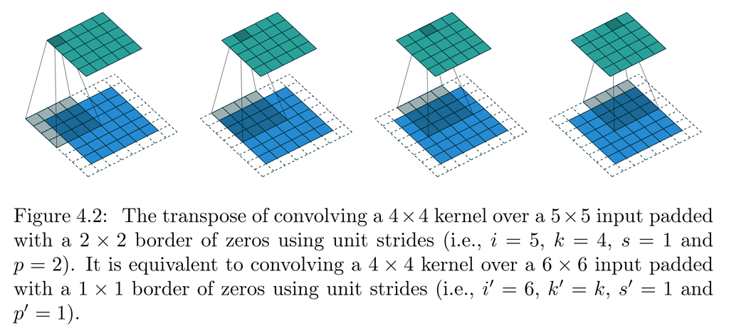

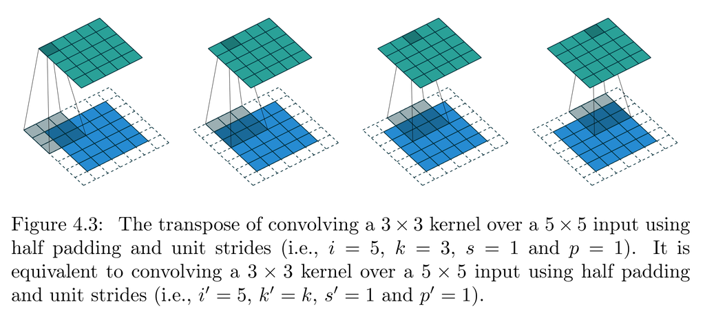

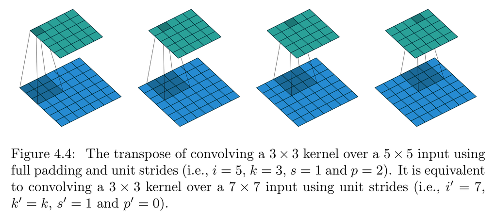

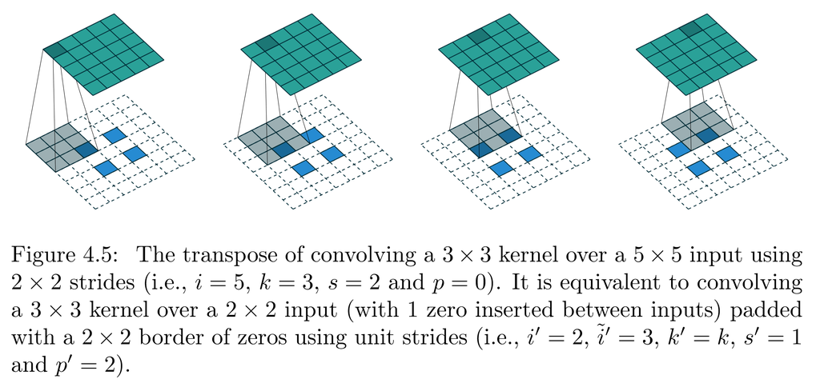

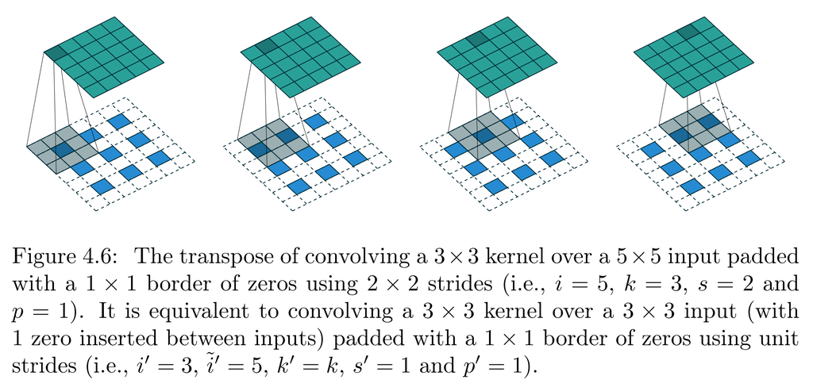

## 1.3. Examples

- A transposed 2-D convolution layer upsamples feature maps.
- This layer is sometimes incorrectly known as a "deconvolution" or "deconv" layer. This layer is the transpose of convolution and does not perform deconvolution.

```python
%%html
<iframe src="https://www.youtube.com/embed/nTt_ajul8NY?start=725"
width="560" height="315" frameborder="0" allowfullscreen></iframe>
```

[video not shown]

## 1.4. CAE with MNIST

**Import Library**

```python
import numpy as np
import matplotlib.pyplot as plt
import tensorflow as tf
%matplotlib inline
```

**Load MNIST Data**

```python
# Load Data

mnist = tf.keras.datasets.mnist
(train_imgs, train_labels), (test_imgs, test_labels) = mnist.load_data()

train_imgs, test_imgs = train_imgs/255.0, test_imgs/255.0
```

```
Downloading data from https://storage.googleapis.com/tensorflow/tf-keras-datasets/mnist.npz
```

- Only use (1, 5, 6) digits to visualize latent space in 2-D

```python
# Use Only 1,5,6 Digits to Visualize

train_x = train_imgs[np.hstack([np.where(train_labels == 1),
                                np.where(train_labels == 5),
                                np.where(train_labels == 6)])][0]
train_y = train_labels[np.hstack([np.where(train_labels == 1),
                                  np.where(train_labels == 5),
                                  np.where(train_labels == 6)])][0]
test_x = test_imgs[np.hstack([np.where(test_labels == 1),
                              np.where(test_labels == 5),
                              np.where(test_labels == 6)])][0]
test_y = test_labels[np.hstack([np.where(test_labels == 1),
                                np.where(test_labels == 5),
                                np.where(test_labels == 6)])][0]
```

```python
train_x = train_x.reshape(-1,28,28,1)
test_x = test_x.reshape(-1,28,28,1)
```

**Build a Model**

```python
encoder = tf.keras.models.Sequential([
    tf.keras.layers.Conv2D(filters = 32,
                           kernel_size = (3,3),
                           strides = (2,2),
                           activation = 'relu',
                           padding = 'SAME',
                           input_shape = (28, 28, 1)),

    tf.keras.layers.Conv2D(filters = 64,
                           kernel_size = (3,3),
                           strides = (2,2),
                           activation = 'relu',
                           padding = 'SAME',
                           input_shape = (14, 14, 32)),

    tf.keras.layers.Conv2D(filters = 2,
                           kernel_size = (7,7),
                           padding = 'VALID',
                           input_shape = (7,7,64))
])
```

```python
decoder = tf.keras.models.Sequential([
    tf.keras.layers.Conv2DTranspose(filters = 64,
                                    kernel_size = (7,7),
                                    strides = (1,1),
                                    activation = 'relu',
                                    padding = 'VALID',
                                    input_shape = (1, 1, 2)),

    tf.keras.layers.Conv2DTranspose(filters = 32,
                                    kernel_size = (3,3),
                                    strides = (2,2),
                                    activation = 'relu',
                                    padding = 'SAME',
                                    input_shape = (7, 7, 64)),

    tf.keras.layers.Conv2DTranspose(filters = 1,
                                    kernel_size = (7,7),
                                    strides = (2,2),
                                    padding = 'SAME',
                                    input_shape = (14,14,32))
])
```

```python
latent = encoder.output
result = decoder(latent)
```

```python
model = tf.keras.Model(inputs = encoder.input, outputs = result)
```

**Define Loss and Optimizer**

```python
model.compile(optimizer = 'adam',
              loss = 'mean_squared_error')
```

**Define Optimization Configuration and Then Optimize**

```python
model.fit(train_x, train_x, epochs = 10)
```

```
<keras.src.callbacks.History at 0x785ab231c490>
```

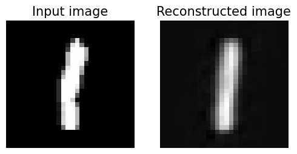

```python
test_img = test_x[[6]]
x_reconst = model.predict(test_img)

plt.figure(figsize = (6, 4))
plt.subplot(1,2,1)
plt.imshow(test_img.reshape(28,28), 'gray')
plt.title('Input image', fontsize = 15)
plt.axis('off')
plt.subplot(1,2,2)
plt.imshow(x_reconst.reshape(28,28), 'gray')
plt.title('Reconstructed image', fontsize = 15)
plt.axis('off')
plt.show()
```

```python
idx = np.random.choice(test_y.shape[0], 500)
rnd_x, rnd_y = test_x[idx], test_y[idx]
```

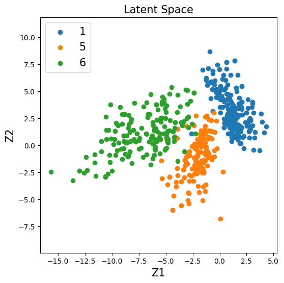

```python
rnd_latent = encoder.predict(rnd_x)
rnd_latent = rnd_latent.reshape(-1,2)

plt.figure(figsize = (6, 6))
plt.scatter(rnd_latent[rnd_y == 1, 0], rnd_latent[rnd_y == 1, 1], label = '1')
plt.scatter(rnd_latent[rnd_y == 5, 0], rnd_latent[rnd_y == 5, 1], label = '5')
plt.scatter(rnd_latent[rnd_y == 6, 0], rnd_latent[rnd_y == 6, 1], label = '6')
plt.title('Latent Space', fontsize = 15)
plt.xlabel('Z1', fontsize = 15)
plt.ylabel('Z2', fontsize = 15)
plt.legend(fontsize = 15)
plt.axis('equal')
plt.show()
```

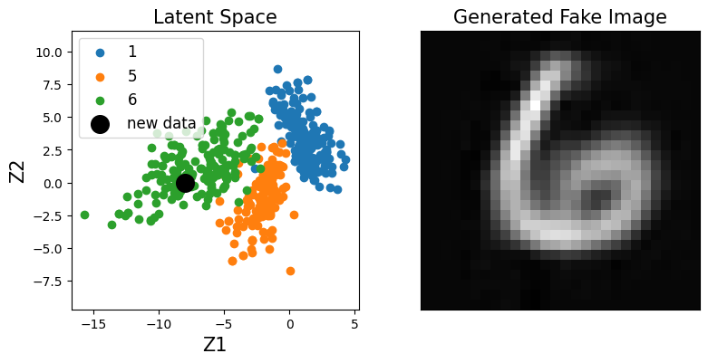

```python
new_latent = np.array([[-8, 0]]).reshape(-1,1,1,2)

fake_img = decoder.predict(new_latent)

plt.figure(figsize = (9, 4))
plt.subplot(1,2,1)
plt.scatter(rnd_latent[rnd_y == 1, 0], rnd_latent[rnd_y == 1, 1], label = '1')
plt.scatter(rnd_latent[rnd_y == 5, 0], rnd_latent[rnd_y == 5, 1], label = '5')
plt.scatter(rnd_latent[rnd_y == 6, 0], rnd_latent[rnd_y == 6, 1], label = '6')
plt.scatter(new_latent[:,:,:,0], new_latent[:,:,:,1], c = 'k', marker = 'o', s = 200, label = 'new data')
plt.title('Latent Space', fontsize = 15)
plt.xlabel('Z1', fontsize = 15)
plt.ylabel('Z2', fontsize = 15)
plt.legend(loc = 2, fontsize = 12)
plt.axis('equal')
plt.subplot(1,2,2)
plt.imshow(fake_img.reshape(28,28), 'gray')
plt.title('Generated Fake Image', fontsize = 15)
plt.xticks([])
plt.yticks([])
plt.show()
```

# 2. Fully Convolutional Networks for Segmentation

```python
from IPython.display import YouTubeVideo
YouTubeVideo('sKDv7yp3Jdk?si=msi2nCF34udI3bUj&amp;start=1230', width = "560", height = "315")
```

[video not shown]

## 2.1. Segmentation

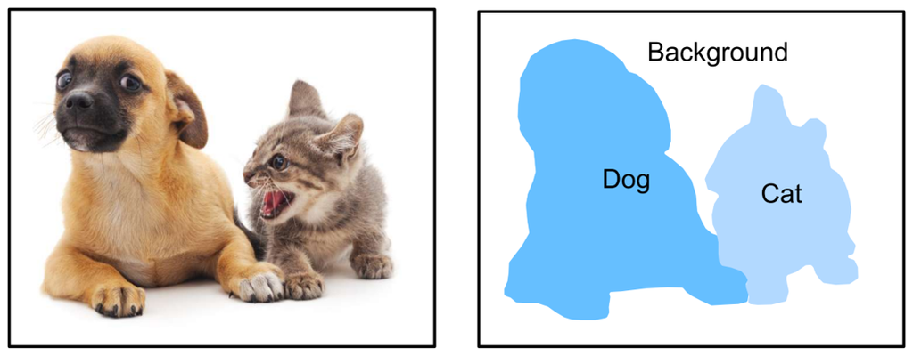

- Segmentation task is different from classification task because it requires predicting a class for each pixel of the input image, instead of only 1 class for the whole input.
- Classification needs to understand what is in the input (namely, the context).
- However, in order to predict what is in the input for each pixel, segmentation needs to recover not only what is in the input, but also where.
- Segment images into regions with different semantic categories. These semantic regions label and predict objects at the pixel level

## 2.2. Fully Convolutional Networks (FCN)

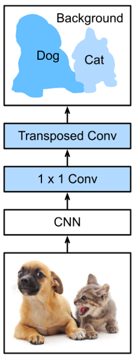

- FCN is built only from locally connected layers, such as convolution, pooling and upsampling.
- Note that no dense layer is used in this kind of architecture.
- Network can work regardless of the original image size, without requiring any fixed number of units at any stage.
- To obtain a segmentation map (output), segmentation networks usually have 2 parts
  - Downsampling path: capture semantic/contextual information
  - Upsampling path: recover spatial information
- The downsampling path is used to extract and interpret the context (what), while the upsampling path is used to enable precise localization (where).
- Furthermore, to fully recover the fine-grained spatial information lost in the pooling or downsampling layers, we often use skip connections.
- Given a position on the spatial dimension, the output of the channel dimension will be a category prediction of the pixel corresponding to the location.

## 2.3. Supervised Learning for Segmentation

### 2.3.1. Segmented (Labeled) Images

Download data

- [seg_train_imgs](https://drive.google.com/file/d/1MUiNwjecC5IEndsAAa0svraikq80E9Dd/view?usp=sharing)
- [seg_train_labels](https://drive.google.com/file/d/1I5VDWWgKcGR4dsPMZeMsaO_3tLMx5djo/view?usp=sharing)
- [seg_test_imgs](https://drive.google.com/file/d/1XUs2dUDKwew0tooAZVVCT-1aEO6_u6dE/view?usp=sharing)

```python
import numpy as np
import matplotlib.pyplot as plt
import tensorflow as tf
```

```python
from google.colab import drive
drive.mount('/content/drive')
```

```python
seg_train_imgs = np.load('/content/drive/MyDrive/DL/DL_data/seg_train_imgs.npy')
seg_train_labels = np.load('/content/drive/MyDrive/DL/DL_data/seg_train_labels.npy')
seg_test_imgs = np.load('/content/drive/MyDrive/DL/DL_data/seg_test_imgs.npy')

n_train = seg_train_imgs.shape[0]
n_test = seg_train_imgs.shape[0]

print ("The number of training images  : {}, shape : {}".format(n_train, seg_train_imgs.shape))
print ("The number of segmented images : {}, shape : {}".format(n_train, seg_train_labels.shape))
print ("The number of testing images   : {}, shape : {}".format(n_test, seg_test_imgs.shape))
```

[output not shown]

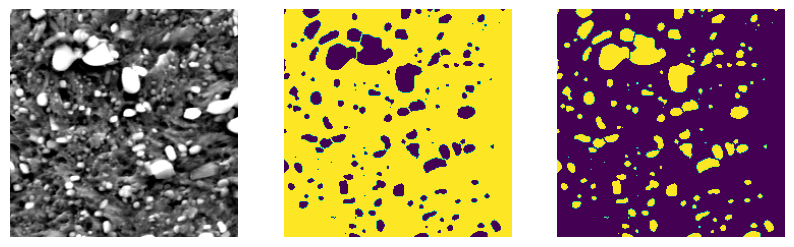

```python
## binary segmentation and one-hot encoding in this case

idx = np.random.randint(n_train)

plt.figure(figsize = (10, 4))
plt.subplot(1,3,1)
plt.imshow(seg_train_imgs[idx])
plt.axis('off')
plt.subplot(1,3,2)
plt.imshow(seg_train_labels[idx][:,:,0])
plt.axis('off')
plt.subplot(1,3,3)
plt.imshow(seg_train_labels[idx][:,:,1])
plt.axis('off')
plt.show()
```

### 2.3.2. From CAE to FCN

- CAE
- FCN
  - VGG16
  - **Skip connections** to fully recover the fine-grained **spatial information** lost in the pooling or downsampling layers

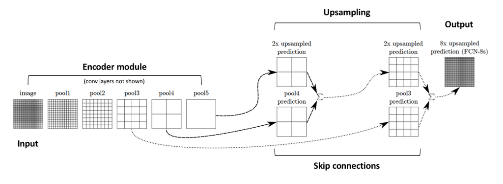

## 2.4. FCN Implementation

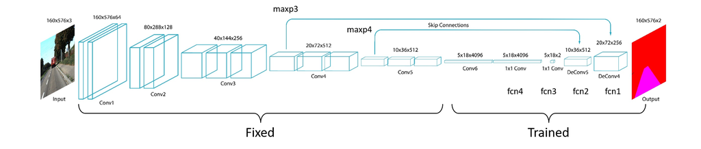

**Utilize VGG16 Model for Encoder**

```python
model_type = tf.keras.applications.vgg16
base_model = model_type.VGG16()
base_model.trainable = False
base_model.summary()
```

```
Model: "vgg16"
_________________________________________________________________
 Layer (type)                Output Shape              Param #
=================================================================
 input_1 (InputLayer)        [(None, 224, 224, 3)]     0

 block1_conv1 (Conv2D)       (None, 224, 224, 64)      1792

 block1_conv2 (Conv2D)       (None, 224, 224, 64)      36928

 block1_pool (MaxPooling2D)  (None, 112, 112, 64)      0

 block2_conv1 (Conv2D)       (None, 112, 112, 128)     73856

 block2_conv2 (Conv2D)       (None, 112, 112, 128)     147584

 block2_pool (MaxPooling2D)  (None, 56, 56, 128)       0

 block3_conv1 (Conv2D)       (None, 56, 56, 256)       295168

 block3_conv2 (Conv2D)       (None, 56, 56, 256)       590080

 block3_conv3 (Conv2D)       (None, 56, 56, 256)       590080

 block3_pool (MaxPooling2D)  (None, 28, 28, 256)       0

 block4_conv1 (Conv2D)       (None, 28, 28, 512)       1180160

 block4_conv2 (Conv2D)       (None, 28, 28, 512)       2359808

 block4_conv3 (Conv2D)       (None, 28, 28, 512)       2359808

 block4_pool (MaxPooling2D)  (None, 14, 14, 512)       0

 block5_conv1 (Conv2D)       (None, 14, 14, 512)       2359808

 block5_conv2 (Conv2D)       (None, 14, 14, 512)       2359808

 block5_conv3 (Conv2D)       (None, 14, 14, 512)       2359808

 block5_pool (MaxPooling2D)  (None, 7, 7, 512)         0

 flatten (Flatten)           (None, 25088)             0

 fc1 (Dense)                 (None, 4096)              102764544

 fc2 (Dense)                 (None, 4096)              16781312

 predictions (Dense)         (None, 1000)              4097000

=================================================================
Total params: 138357544 (527.79 MB)
Trainable params: 0 (0.00 Byte)
Non-trainable params: 138357544 (527.79 MB)
_________________________________________________________________
```

**Build a FCN Model**

- tf.layers are used to define upsampling parts

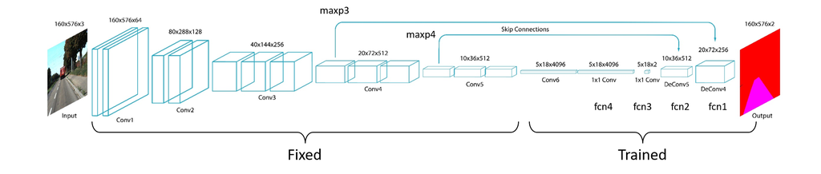

```python
map5 = base_model.layers[-5].output

# sixth convolution layer
conv6 = tf.keras.layers.Conv2D(filters = 4096,
                               kernel_size = (7,7),
                               padding = 'SAME',
                               activation = 'relu')(map5)

# 1x1 convolution layers
fcn4 = tf.keras.layers.Conv2D(filters = 4096,
                              kernel_size = (1,1),
                              padding = 'SAME',
                              activation = 'relu')(conv6)

fcn3 = tf.keras.layers.Conv2D(filters = 2,
                              kernel_size = (1,1),
                              padding = 'SAME',
                              activation = 'relu')(fcn4)

# Upsampling layers
fcn2 =  tf.keras.layers.Conv2DTranspose(filters = 512,
                                        kernel_size = (4,4),
                                        strides = (2,2),
                                        padding = 'SAME')(fcn3)

fcn1 =  tf.keras.layers.Conv2DTranspose(filters = 256,
                                        kernel_size = (4,4),
                                        strides = (2,2),
                                        padding = 'SAME')(fcn2 + base_model.layers[14].output)

output =  tf.keras.layers.Conv2DTranspose(filters = 2,
                                          kernel_size = (16,16),
                                          strides = (8,8),
                                          padding = 'SAME',
                                          activation = 'softmax')(fcn1 + base_model.layers[10].output)

model = tf.keras.Model(inputs = base_model.inputs, outputs = output)
```

```python
model.summary()
```

```
Model: "model"
__________________________________________________________________________________________________
 Layer (type)                Output Shape                 Param #   Connected to
==================================================================================================
 input_1 (InputLayer)        [(None, 224, 224, 3)]        0         []

 block1_conv1 (Conv2D)       (None, 224, 224, 64)         1792      ['input_1[0][0]']

 block1_conv2 (Conv2D)       (None, 224, 224, 64)         36928     ['block1_conv1[0][0]']

 block1_pool (MaxPooling2D)  (None, 112, 112, 64)         0         ['block1_conv2[0][0]']

 block2_conv1 (Conv2D)       (None, 112, 112, 128)        73856     ['block1_pool[0][0]']

 block2_conv2 (Conv2D)       (None, 112, 112, 128)        147584    ['block2_conv1[0][0]']

 block2_pool (MaxPooling2D)  (None, 56, 56, 128)          0         ['block2_conv2[0][0]']

 block3_conv1 (Conv2D)       (None, 56, 56, 256)          295168    ['block2_pool[0][0]']

 block3_conv2 (Conv2D)       (None, 56, 56, 256)          590080    ['block3_conv1[0][0]']

 block3_conv3 (Conv2D)       (None, 56, 56, 256)          590080    ['block3_conv2[0][0]']

 block3_pool (MaxPooling2D)  (None, 28, 28, 256)          0         ['block3_conv3[0][0]']

 block4_conv1 (Conv2D)       (None, 28, 28, 512)          1180160   ['block3_pool[0][0]']

 block4_conv2 (Conv2D)       (None, 28, 28, 512)          2359808   ['block4_conv1[0][0]']

 block4_conv3 (Conv2D)       (None, 28, 28, 512)          2359808   ['block4_conv2[0][0]']

 block4_pool (MaxPooling2D)  (None, 14, 14, 512)          0         ['block4_conv3[0][0]']

 block5_conv1 (Conv2D)       (None, 14, 14, 512)          2359808   ['block4_pool[0][0]']

 block5_conv2 (Conv2D)       (None, 14, 14, 512)          2359808   ['block5_conv1[0][0]']

 block5_conv3 (Conv2D)       (None, 14, 14, 512)          2359808   ['block5_conv2[0][0]']

```

[output cut: 15 more lines]

```

 conv2d_transpose_1 (Conv2D  (None, 28, 28, 256)          2097408   ['tf.__operators__.add[0][0]']
 Transpose)

 tf.__operators__.add_1 (TF  (None, 28, 28, 256)          0         ['conv2d_transpose_1[0][0]',
 OpLambda)                                                           'block3_pool[0][0]']

 conv2d_transpose_2 (Conv2D  (None, 224, 224, 2)          131074    ['tf.__operators__.add_1[0][0]
 Transpose)                                                         ']

==================================================================================================
Total params: 136514116 (520.76 MB)
Trainable params: 121799428 (464.63 MB)
Non-trainable params: 14714688 (56.13 MB)
__________________________________________________________________________________________________
```

**Training**

```python
model.compile(optimizer = 'adam',
              loss = 'categorical_crossentropy',
              metrics = ['accuracy'])
```

```python
model.fit(seg_train_imgs, seg_train_labels, batch_size = 5, epochs = 5)
```

```
<keras.src.callbacks.History at 0x7fcf20508fa0>
```

**Testing**

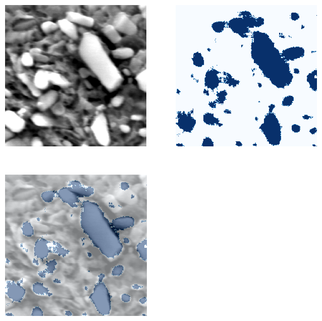

```python
test_img = seg_test_imgs[[1]]
test_segmented = model.predict(test_img)

seg_mask = (test_segmented[:,:,:,1] > 0.5).reshape(224, 224, 1).astype(float)

plt.figure(figsize = (8,8))
plt.subplot(2,2,1)
plt.imshow(test_img[0])
plt.axis('off')
plt.subplot(2,2,2)
plt.imshow(seg_mask, cmap = 'Blues')
plt.axis('off')
plt.subplot(2,2,3)
plt.imshow(test_img[0])
plt.imshow(seg_mask, cmap = 'Blues', alpha = 0.5)
plt.axis('off')
plt.show()
```

# 3. Super-resolution and Deblurring

```python
from IPython.display import YouTubeVideo
YouTubeVideo('7h91Q94E7aw?si=_jEnWdl_Hw3hBx90&amp;start=511', width = "560", height = "315")
```

[video not shown]

## 3.1. Image Restoration

[figure not shown]

- Image restoration tries to recover original image from degraded one with prior knowledge of degradation process.
- The sources of corruption in digital images arise during image acquisition (digitization) and transmission.
  - Imaging sensors can be affected by ambient conditions.
  - Interference can be added to an image during transmission.

## 3.2. Inverse Problem

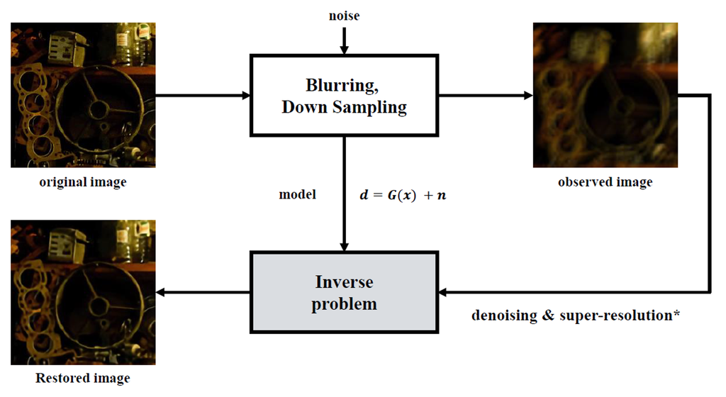

- The reconstruction is the inverse of the acquisition.
- Inverse problems involve modeling of degradation and applying the inverse process in order to recover the original image from inadequate observations.
- The observations contain incomplete information about the target parameter or data due to physical limitations of the measurement devices.
- Consequently, solutions to inverse problems are non-unique.

## 3.3. Image Super-resolution

- Restore High Resolution (HR) image from Low Resolution (LR) image

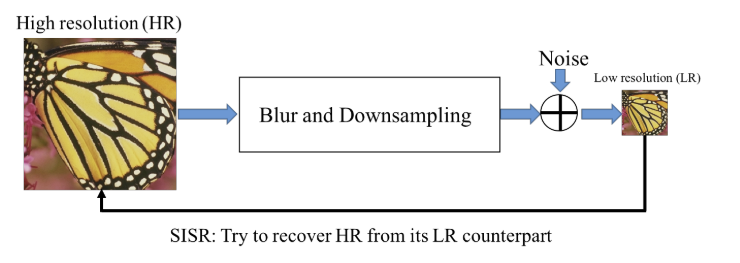

- There are numerous learning-based SR approaches.

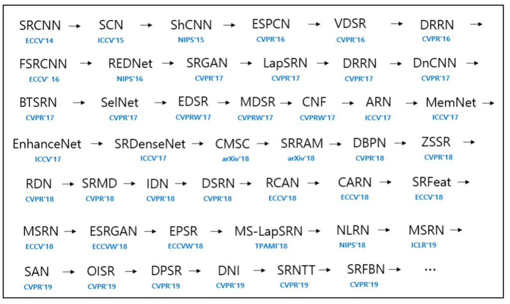

**HR and LR Images**

Download data from here

- [High resolution train](https://drive.google.com/file/d/1Yr5A1N1zopCzBZHsnm6LBDyzq8CisXM_/view?usp=sharing)
- [High resolution test](https://drive.google.com/file/d/16xYK_CTkqoTeoYO6Cfu-pJG63Ri8li-i/view?usp=sharing)
- [Low resolution train](https://drive.google.com/file/d/1v85JJVde8w4s9t-yYOVK8zz_4STIYPYr/view?usp=sharing)
- [Low resolution test](https://drive.google.com/file/d/1_agRDVldY_AZdR33PsnXi3jeCT2rFc1p/view?usp=sharing)

```python
import numpy as np
import matplotlib.pyplot as plt
import tensorflow as tf
```

```python
from google.colab import drive
drive.mount('/content/drive')
```

```python
train_lr = np.load('/content/drive/MyDrive/DL/DL_data/SR_train_lr.npy')
train_hr = np.load('/content/drive/MyDrive/DL/DL_data/SR_train_hr.npy')
test_lr = np.load('/content/drive/MyDrive/DL/DL_data/SR_test_lr.npy')

n_train = train_lr.shape[0]
n_test = test_lr.shape[0]

print ("The number of training LR images : {}, shape : {}".format(n_train, train_lr.shape))
print ("The number of training HR images : {}, shape : {}".format(n_train, train_hr.shape))
print ("The number of testing LR images  : {}, shape : {}".format(n_test, test_lr.shape))
```

```
The number of training LR images : 79, shape : (79, 112, 112, 1)
The number of training HR images : 79, shape : (79, 224, 224, 1)
The number of testing LR images  : 20, shape : (20, 112, 112, 1)
```

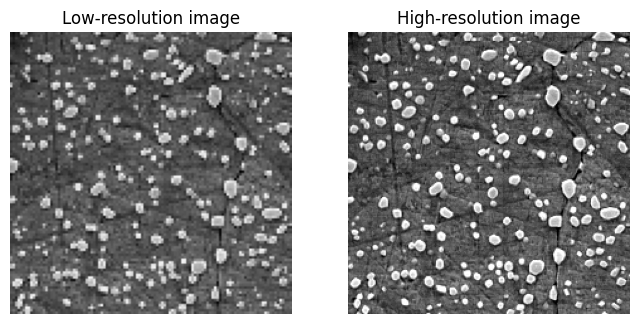

```python
idx = np.random.randint(n_train)

plt.figure(figsize = (8, 6))
plt.subplot(1,2,1)
plt.imshow(train_lr[idx][:,:,0], 'gray')
plt.title('Low-resolution image')
plt.axis('off')
plt.subplot(1,2,2)
plt.imshow(train_hr[idx][:,:,0], 'gray')
plt.title('High-resolution image')
plt.axis('off')
plt.show()
```

**Build a FCN Model**

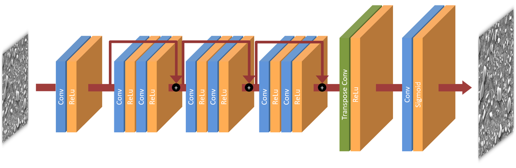

```python
inputs = tf.keras.Input(shape = (112, 112, 1))

# 3x3 convolutional layer
x = tf.keras.layers.Conv2D(filters = 16,
                           kernel_size = (3,3),
                           padding = 'SAME',
                           activation = 'relu')(inputs)

# first residual block
x_skip = x
x = tf.keras.layers.Conv2D(filters = 16,
                           kernel_size = (3,3),
                           padding = 'SAME',
                           activation = 'relu')(x)

x = tf.keras.layers.Conv2D(filters = 16,
                           kernel_size = (3,3),
                           padding = 'SAME',
                           activation = 'relu')(x)

x = tf.keras.layers.Add()([x_skip, x])

# second residual block
x_skip = x
x = tf.keras.layers.Conv2D(filters = 16,
                           kernel_size = (3,3),
                           padding = 'SAME',
                           activation = 'relu')(x)

x = tf.keras.layers.Conv2D(filters = 16,
                           kernel_size = (3,3),
                           padding = 'SAME',
                           activation = 'relu')(x)

x = tf.keras.layers.Add()([x_skip, x])

# third residual block
x_skip = x
x = tf.keras.layers.Conv2D(filters = 16,
                           kernel_size = (3,3),
                           padding = 'SAME',
                           activation = 'relu')(x)

x = tf.keras.layers.Conv2D(filters = 16,
                           kernel_size = (3,3),
                           padding = 'SAME',
                           activation = 'relu')(x)

x = tf.keras.layers.Add()([x_skip, x])

# upsampling layer
x = tf.keras.layers.Conv2DTranspose(filters = 16,
                                    kernel_size = (4,4),
                                    strides = (2,2),
                                    padding = 'SAME',
                                    activation = 'relu')(x)

# 3x3 convolutional layer
outputs = tf.keras.layers.Conv2D(filters = 1,
                                 kernel_size = (3,3),
                                 padding = 'SAME',
                                 activation = 'sigmoid')(x)

model = tf.keras.Model(inputs, outputs)
```

**Training**

```python
model.compile(optimizer = 'adam',
              loss = 'mean_absolute_error',
              metrics = ['mean_squared_error'])
```

```python
model.fit(train_lr, train_hr, batch_size = 16, epochs = 30)
```

```
<keras.src.callbacks.History at 0x7b0d28239c30>
```

**Testing**

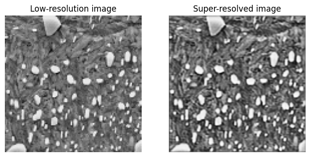

```python
test_x = test_lr[[3]]
test_sr = model.predict(test_x)

plt.figure(figsize = (8, 6))
plt.subplot(1,2,1)
plt.imshow(test_x[0][:,:,0], 'gray')
plt.title('Low-resolution image')
plt.axis('off')
plt.subplot(1,2,2)
plt.imshow(test_sr[0][:,:,0], 'gray')
plt.title('Super-resolved image')
plt.axis('off')
plt.show()
```

# 4. Image Deblurring

**Blurred and Deblurred Images**

Download data from here

- [deblurring_train_blur](https://drive.google.com/file/d/1Abe1c-9X0ze1g8ouEx2KMzRs_CkzJm5g/view?usp=sharing)
- [deblurring_test_blur](https://drive.google.com/file/d/1lU5BZLa_6zMzlj3goATUuZCGFE25u_sD/view?usp=sharing)
- [deblurring_train_deblur](https://drive.google.com/file/d/1HsbtuoyLEDtIpCYjsMclA2bhYaUC1VIs/view?usp=sharing)
- [deblurring_test_deblur](https://drive.google.com/file/d/1R1hoKqrEdI5C82Iq8KW2YGu44Qrn1gKY/view?usp=sharing)

```python
train_blur = np.load('/content/drive/MyDrive/DL_Colab/DL_data/deblurring_train_blur.npy')
train_deblur = np.load('/content/drive/MyDrive/DL_Colab/DL_data/deblurring_train_deblur.npy')
test_blur = np.load('/content/drive/MyDrive/DL_Colab/DL_data/deblurring_test_blur.npy')

n_train = train_blur.shape[0]
n_test = test_blur.shape[0]

print ("The number of training blur images   : {}, shape : {}".format(n_train, train_blur.shape))
print ("The number of training deblur images : {}, shape : {}".format(n_train, train_deblur.shape))
print ("The number of testing blur images    : {}, shape : {}".format(n_test, test_blur.shape))
```

```
The number of training blur images   : 79, shape : (79, 224, 224, 1)
The number of training deblur images : 79, shape : (79, 224, 224, 1)
The number of testing blur images    : 20, shape : (20, 224, 224, 1)
```

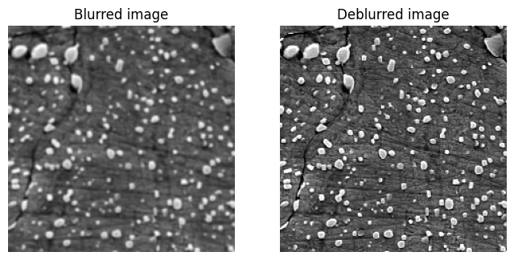

```python
idx = np.random.randint(n_train)

plt.figure(figsize = (8, 6))
plt.subplot(1,2,1)
plt.imshow(train_blur[idx][:,:,0], 'gray')
plt.title('Blurred image')
plt.axis('off')
plt.subplot(1,2,2)
plt.imshow(train_deblur[idx][:,:,0], 'gray')
plt.title('Deblurred image')
plt.axis('off')
plt.show()
```

**Build a FCN Model**

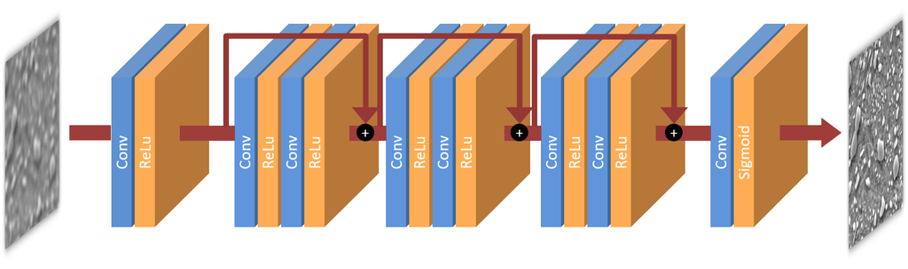

```python
inputs = tf.keras.Input(shape = (224, 224, 1))

# 3x3 convolutional layer
x = tf.keras.layers.Conv2D(filters = 16,
                           kernel_size = (3,3),
                           padding = 'SAME',
                           activation = 'relu')(inputs)

# first residual block
x_skip = x
x = tf.keras.layers.Conv2D(filters = 16,
                           kernel_size = (3,3),
                           padding = 'SAME',
                           activation = 'relu')(x)

x = tf.keras.layers.Conv2D(filters = 16,
                           kernel_size = (3,3),
                           padding = 'SAME',
                           activation = 'relu')(x)

x = tf.keras.layers.Add()([x_skip, x])

# second residual block
x_skip = x
x = tf.keras.layers.Conv2D(filters = 16,
                           kernel_size = (3,3),
                           padding = 'SAME',
                           activation = 'relu')(x)

x = tf.keras.layers.Conv2D(filters = 16,
                           kernel_size = (3,3),
                           padding = 'SAME',
                           activation = 'relu')(x)

x = tf.keras.layers.Add()([x_skip, x])

# third residual block
x_skip = x
x = tf.keras.layers.Conv2D(filters = 16,
                           kernel_size = (3,3),
                           padding = 'SAME',
                           activation = 'relu')(x)

x = tf.keras.layers.Conv2D(filters = 16,
                           kernel_size = (3,3),
                           padding = 'SAME',
                           activation = 'relu')(x)

x = tf.keras.layers.Add()([x_skip, x])

# 3x3 convolutional layer
outputs = tf.keras.layers.Conv2D(filters = 1,
                                 kernel_size = (3,3),
                                 padding = 'SAME',
                                 activation = 'sigmoid')(x)

model = tf.keras.Model(inputs, outputs)
```

**Training**

```python
model.compile(optimizer = 'adam',
              loss ='mean_absolute_error',
              metrics = ['mean_squared_error'])
```

```python
model.fit(train_blur, train_deblur, batch_size = 16, epochs = 30)
```

```
<keras.src.callbacks.History at 0x7b0cfffc50c0>
```

**Testing**

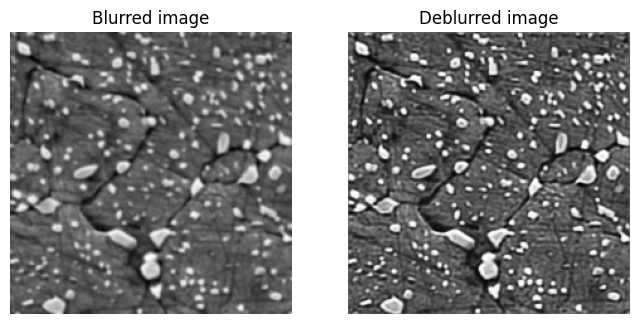

```python
test_x = test_blur[[1]]
test_deblur = model.predict(test_x)

plt.figure(figsize = (8, 6))
plt.subplot(1,2,1)
plt.imshow(test_x[0][:,:,0], 'gray')
plt.title('Blurred image')
plt.axis('off')
plt.subplot(1,2,2)
plt.imshow(test_deblur[0][:,:,0], 'gray')
plt.title('Deblurred image')
plt.axis('off')
plt.show()
```

```python
%%javascript
$.getScript('https://kmahelona.github.io/ipython_notebook_goodies/ipython_notebook_toc.js')
```